# MITx_4_Trees

Raka

10/19/2020

## Understanding why people vote?

In August 2006 three researchers (Alan Gerber and Donald Green of Yale University, and Christopher Larimer of the University of Northern Iowa) carried out a large scale field experiment in Michigan, USA to test the hypothesis that one of the reasons people vote is social, or extrinsic, pressure. To quote the first paragraph of their 2008 research paper:

```
Among the most striking features of a democratic political system is the participation of millions of voters in elections. Why do large numbers of people vote, despite the fact that ... "the casting of a single vote is of no significance where there is a multitude of electors"? One hypothesis is adherence to social norms. Voting is widely regarded as a citizen duty, and citizens worry that others will think less of them if they fail to participate in elections. Voters' sense of civic duty has long been a leading explanation of vote turnout...
```

We will first get familiar with the data. Load the CSV file gerber.csv into R. What proportion of people in this dataset voted in this election?

```r
vote <- read.csv("gerber.csv")
str(vote)
```

```
## 'data.frame':    344084 obs. of  8 variables:
##  $ sex      : int  0 1 1 1 0 1 0 0 1 0 ...
##  $ yob      : int  1941 1947 1982 1950 1951 1959 1956 1981 1968 1967 ...
##  $ voting   : int  0 0 1 1 1 1 1 0 0 0 ...
##  $ hawthorne: int  0 0 1 1 1 0 0 0 0 0 ...
##  $ civicduty: int  1 1 0 0 0 0 0 0 0 0 ...
##  $ neighbors: int  0 0 0 0 0 0 0 0 0 0 ...
##  $ self     : int  0 0 0 0 0 0 0 0 0 0 ...
##  $ control  : int  0 0 0 0 0 1 1 1 1 1 ...
```

```r
summary(vote)
```

```
##       sex              yob           voting         hawthorne
##  Min.   :0.0000   Min.   :1900   Min.   :0.0000   Min.   :0.000
##  1st Qu.:0.0000   1st Qu.:1947   1st Qu.:0.0000   1st Qu.:0.000
##  Median :0.0000   Median :1956   Median :0.0000   Median :0.000
##  Mean   :0.4993   Mean   :1956   Mean   :0.3159   Mean   :0.111
##  3rd Qu.:1.0000   3rd Qu.:1965   3rd Qu.:1.0000   3rd Qu.:0.000
##  Max.   :1.0000   Max.   :1986   Max.   :1.0000   Max.   :1.000
##    civicduty        neighbors          self           control
##  Min.   :0.0000   Min.   :0.000   Min.   :0.0000   Min.   :0.0000
##  1st Qu.:0.0000   1st Qu.:0.000   1st Qu.:0.0000   1st Qu.:0.0000
##  Median :0.0000   Median :0.000   Median :0.0000   Median :1.0000
##  Mean   :0.1111   Mean   :0.111   Mean   :0.1111   Mean   :0.5558
##  3rd Qu.:0.0000   3rd Qu.:0.000   3rd Qu.:0.0000   3rd Qu.:1.0000
##  Max.   :1.0000   Max.   :1.000   Max.   :1.0000   Max.   :1.0000
```

```r
table(vote$voting)/nrow(vote)
```

```
##
##         0         1
## 0.6841004 0.3158996
```

# Finding the largest voter group

Which of the four “treatment groups” had the largest percentage of people who actually voted (voting = 1)?

```r
table(vote$voting, vote$hawthorne)/ nrow(vote)
```

```
##
##              0          1
##   0 0.60886295 0.07523744
##   1 0.28010602 0.03579359
```

```r
table(vote$voting, vote$civicduty)/ nrow(vote)
```

```
##
##              0          1
##   0 0.60796492 0.07613548
##   1 0.28096337 0.03493624
```

```r
table(vote$voting, vote$neighbors)/ nrow(vote)
```

```
##
##              0          1
##   0 0.61503877 0.06906162
##   1 0.27393892 0.04196068
```

```r
table(vote$voting, vote$self)/ nrow(vote)
```

```
##
##              0          1
##   0 0.61136525 0.07273515
##   1 0.27756304 0.03833657
```

```r
table(vote$voting, vote$control)/ nrow(vote)
```

```
##
##             0         1
##   0 0.2931697 0.3909307
##   1 0.1510271 0.1648725
```

# Exploration and logistic regression

Build a logistic regression model for voting using the four treatment group variables as the independent variables (civicduty, hawthorne, self, and neighbors). Use all the data to build the model (DO NOT split the data into a training set and testing set). Which of the following coefficients are significant in the logistic regression model? Select all that apply.

```r
logVote <- glm(voting ~ civicduty + hawthorne + self + neighbors, data = vote, family = binomial)
summary(logVote)
```

```
##
## Call:
## glm(formula = voting ~ civicduty + hawthorne + self + neighbors,
##     family = binomial, data = vote)
##
## Deviance Residuals:
##     Min       1Q   Median       3Q      Max
## -0.9744  -0.8691  -0.8389   1.4586   1.5590
##
## Coefficients:
##              Estimate Std. Error  z value Pr(>|z|)
## (Intercept) -0.863358   0.005006 -172.459  < 2e-16 ***
## civicduty    0.084368   0.012100    6.972 3.12e-12 ***
## hawthorne    0.120477   0.012037   10.009  < 2e-16 ***
## self         0.222937   0.011867   18.786  < 2e-16 ***
## neighbors    0.365092   0.011679   31.260  < 2e-16 ***
## ---
## Signif. codes:  0 '***' 0.001 '**' 0.01 '*' 0.05 '.' 0.1 ' ' 1
##
## (Dispersion parameter for binomial family taken to be 1)
##
##     Null deviance: 429238  on 344083  degrees of freedom
## Residual deviance: 428090  on 344079  degrees of freedom
## AIC: 428100
##
## Number of Fisher Scoring iterations: 4
```

# Prediction

Using a threshold of 0.3, what is the accuracy of the logistic regression model? (When making predictions, you don’t need to use the newdata argument since we didn’t split our data.)

```r
predicted <- predict(logVote, type = 'response')
# confusion matrix
table(vote$voting, predicted > 0.3)
```

```
##
##      FALSE   TRUE
##   0 134513 100875
##   1  56730  51966
```

```r
(134513+51966)/nrow(vote)
```

```
## [1] 0.5419578
```

```r
# with higher threshold
table(vote$voting, predicted > 0.5)
```

```
##
##      FALSE
##   0 235388
##   1 108696
```

```r
(235388)/nrow(vote)
```

```
## [1] 0.6841004
```

# Area under Curve with ROCR

Compare your previous two answers to the percentage of people who did not vote (the baseline accuracy) and compute the AUC of the model. What is happening here?

```r
library(ROCR)
ROCRpred <- prediction(predicted, vote$voting)
as.numeric(performance(ROCRpred, "auc")@y.values)
```

```
## [1] 0.5308461
```

# Problem 2: TREES

We will now try out trees. Build a CART tree for voting using all data and the same four treatment variables we used before. Don’t set the option method=“class” - we are actually going to create a regression tree here. We are interested in building a tree to explore the fraction of people who vote, or the probability of voting. We’d like CART to split our groups if they have different probabilities of voting. If we used method=‘class’, CART would only split if one of the groups had a probability of voting above 50% and the other had a probability of voting less than 50% (since the predicted outcomes would be different). However, with regression trees, CART will split even if both groups have probability less than 50%.

Leave all the parameters at their default values. You can use the following command in R to build the tree:

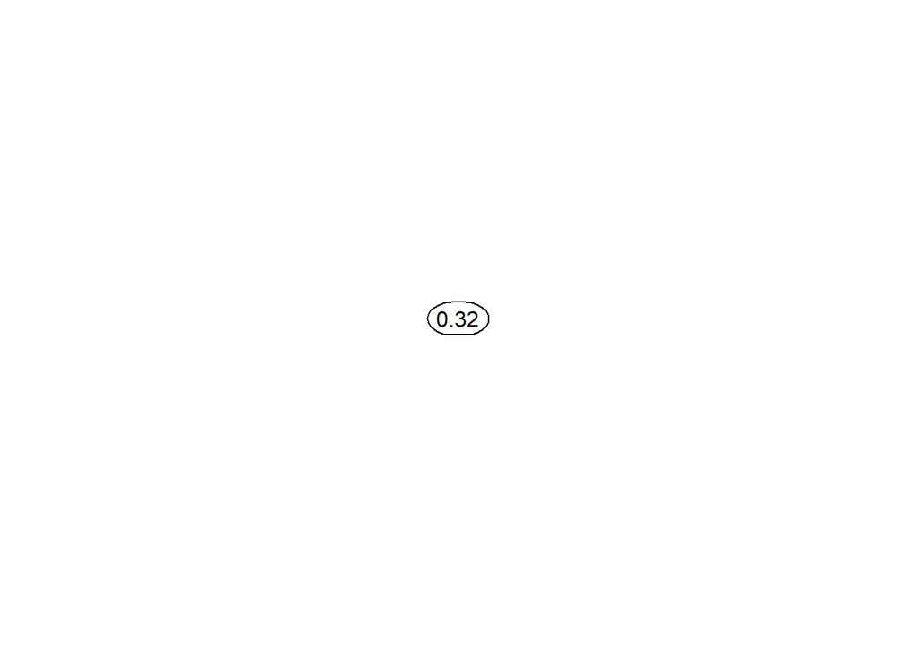

```r
library(rpart)
library(rpart.plot)
CARTmodel <- rpart(voting ~ civicduty + hawthorne + self + neighbors, data=vote)
prp(CARTmodel)
```

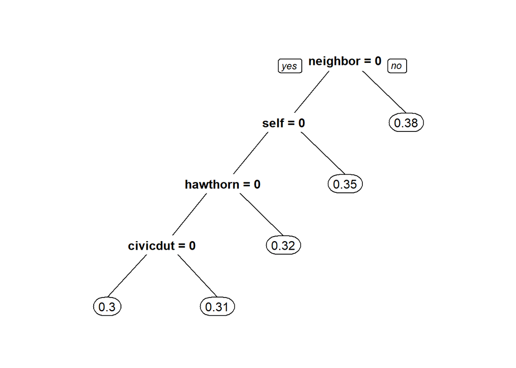

```r
# repeat with other model, prev result was bad

CARTmodel2 <-  rpart(voting ~ civicduty + hawthorne + self + neighbors, data=vote, cp=0.0)
prp(CARTmodel2)
```

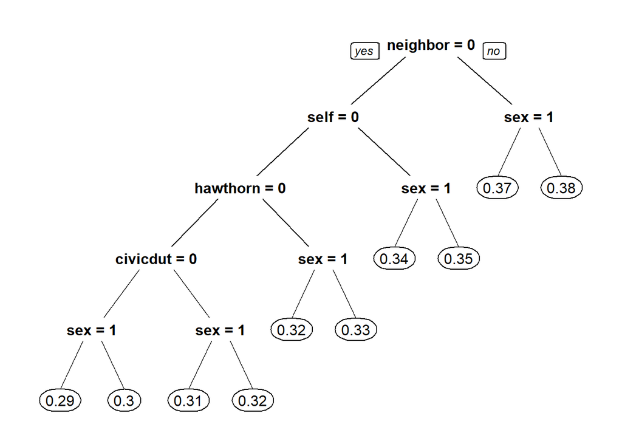

```r
# Another model with sex

CARTmodel3 <-  rpart(voting ~ civicduty + hawthorne + self + neighbors + sex, data=vote, cp=0.0)
prp(CARTmodel3)
```

# Interaction terms

We know trees can handle “nonlinear” relationships, e.g. “in the ‘Civic Duty’ group and female”, but as we will see in the next few questions, it is possible to do the same for logistic regression. First, let’s explore what trees can tell us some more.

Let’s just focus on the “Control” treatment group. Create a regression tree using just the “control” variable, then create another tree with the “control” and “sex” variables, both with cp=0.0.

In the “control” only tree, what is the absolute value of the difference in the predicted probability of voting between being in the control group versus being in a different group? You can use the absolute value function to get answer, i.e. abs(Control Prediction - Non-Control Prediction). Add the argument “digits = 6” to the prp command to get a more accurate estimate.

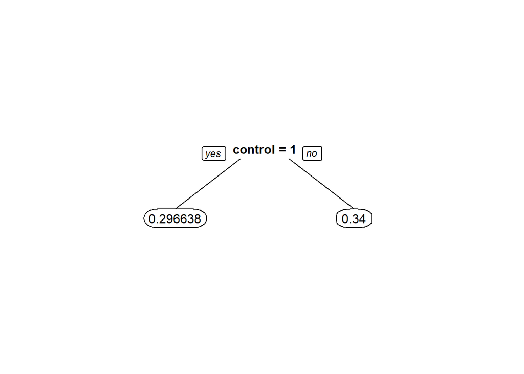

```r
CARTmodel4 <- rpart(voting ~ control, data=vote, cp = 0.0)
prp(CARTmodel4, digits = 6)
```

```r
abs(0.296638 - 0.34)
```

```
## [1] 0.043362
```

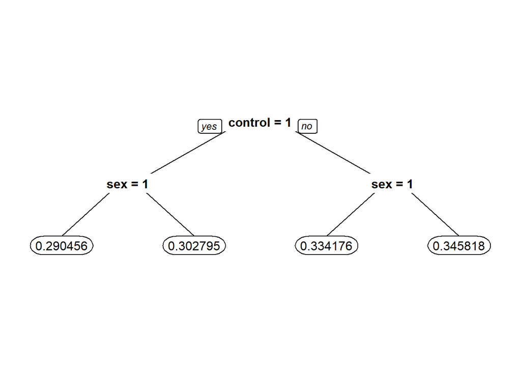

```r
CARTmodel5 <- rpart(voting ~ control + sex, data=vote, cp = 0.0)
prp(CARTmodel5, digits = 6)
```

```r
# Back to regression model
LogReg2 <- glm(voting ~ control + sex, data = vote, family = binomial)
summary(LogReg2)
```

```
##
## Call:
## glm(formula = voting ~ control + sex, family = binomial, data = vote)
##
## Deviance Residuals:
##     Min       1Q   Median       3Q      Max
## -0.9220  -0.9012  -0.8290   1.4564   1.5717
##
## Coefficients:
##              Estimate Std. Error z value Pr(>|z|)
## (Intercept) -0.635538   0.006511 -97.616  < 2e-16 ***
## control     -0.200142   0.007364 -27.179  < 2e-16 ***
## sex         -0.055791   0.007343  -7.597 3.02e-14 ***
## ---
## Signif. codes:  0 '***' 0.001 '**' 0.01 '*' 0.05 '.' 0.1 ' ' 1
##
## (Dispersion parameter for binomial family taken to be 1)
##
##     Null deviance: 429238  on 344083  degrees of freedom
## Residual deviance: 428443  on 344081  degrees of freedom
## AIC: 428449
##
## Number of Fisher Scoring iterations: 4
```

# Interaction terms 2

The regression tree calculated the percentage voting exactly for every one of the four possibilities (Man, Not Control), (Man, Control), (Woman, Not Control), (Woman, Control). However, logistic regression on the “sex” and “control” variables considers these variables separately, not jointly, and therefore did not do as well.

We can quantify this precisely. Create the following dataframe (this contains all of the possible values of sex and control), and evaluate your logistic regression using the predict function (where “LogModelSex” is the name of your logistic regression model that uses both control and sex):

```r
Possibilities <-  data.frame(sex=c(0,0,1,1),control=c(0,1,0,1))
predict(LogReg2, newdata=Possibilities, type="response")
```

```
##         1         2         3         4
## 0.3462559 0.3024455 0.3337375 0.2908065
```

```r
# the diff
abs(0.2908065 - 0.290456)
```

```
## [1] 0.0003505
```

# Interaction terms 3

So the difference is not too big for this dataset, but it is there. We’re going to add a new term to our logistic regression now, that is the combination of the “sex” and “control” variables - so if this new variable is 1, that means the person is a woman AND in the control group. We can do that with the following command:

```r
# combination of sex and control together
LogModel2 <-  glm(voting ~ sex + control + sex:control, data=vote, family="binomial")
summary(LogModel2)
```

```
##
## Call:
## glm(formula = voting ~ sex + control + sex:control, family = "binomial",
##     data = vote)
##
## Deviance Residuals:
##     Min       1Q   Median       3Q      Max
## -0.9213  -0.9019  -0.8284   1.4573   1.5724
##
## Coefficients:
##              Estimate Std. Error z value Pr(>|z|)
## (Intercept) -0.637471   0.007603 -83.843  < 2e-16 ***
## sex         -0.051888   0.010801  -4.804 1.55e-06 ***
## control     -0.196553   0.010356 -18.980  < 2e-16 ***
## sex:control -0.007259   0.014729  -0.493    0.622
## ---
## Signif. codes:  0 '***' 0.001 '**' 0.01 '*' 0.05 '.' 0.1 ' ' 1
##
## (Dispersion parameter for binomial family taken to be 1)
##
##     Null deviance: 429238  on 344083  degrees of freedom
## Residual deviance: 428442  on 344080  degrees of freedom
## AIC: 428450
##
## Number of Fisher Scoring iterations: 4
```

```r
predicted_2 <- predict(LogModel2, newdata=Possibilities, type="response")
predicted_2
```

```
##         1         2         3         4
## 0.3458183 0.3027947 0.3341757 0.2904558
```

```r
abs(0.2904558 - 0.290456)
```

```
## [1] 2e-07
```

## Letter Recognition

Let’s warm up by attempting to predict just whether a letter is B or not. To begin, load the file letters_ABPR.csv into R, and call it letters. Then, create a new variable isB in the dataframe, which takes the value “TRUE” if the observation corresponds to the letter B, and “FALSE” if it does not. You can do this by typing the following command into your R console:

letters$isB = as.factor(letters$letter == “B”)

Now split the data set into a training and testing set, putting 50% of the data in the training set. Set the seed to 1000 before making the split. The first argument to sample.split should be the dependent variable “letters$isB”. Remember that TRUE values from sample.split should go in the training set.

Before building models, let’s consider a baseline method that always predicts the most frequent outcome, which is “not B”. What is the accuracy of this baseline method on the test set?

```r
library(caTools)
letters <- read.csv("letters_ABPR.csv")
str(letters)
```

```
## 'data.frame':    3116 obs. of  17 variables:
##  $ letter   : chr  "B" "A" "R" "B" ...
##  $ xbox     : int  4 1 5 5 3 8 2 3 8 6 ...
##  $ ybox     : int  2 1 9 9 6 10 6 7 14 10 ...
##  $ width    : int  5 3 5 7 4 8 4 5 7 8 ...
##  $ height   : int  4 2 7 7 4 6 4 5 8 8 ...
##  $ onpix    : int  4 1 6 10 2 6 3 3 4 7 ...
##  $ xbar     : int  8 8 6 9 4 7 6 12 5 8 ...
##  $ ybar     : int  7 2 11 8 14 7 7 2 10 5 ...
##  $ x2bar    : int  6 2 7 4 8 3 5 3 6 7 ...
##  $ y2bar    : int  6 2 3 4 1 5 5 2 3 5 ...
##  $ xybar    : int  7 8 7 6 11 8 6 10 12 7 ...
##  $ x2ybar   : int  6 2 3 8 6 4 5 2 5 6 ...
##  $ xy2bar   : int  6 8 9 6 3 8 7 9 4 6 ...
##  $ xedge    : int  2 1 2 6 0 6 3 2 4 3 ...
##  $ xedgeycor: int  8 6 7 11 10 6 7 6 10 9 ...
##  $ yedge    : int  7 2 5 8 4 7 5 3 4 8 ...
##  $ yedgexcor: int  10 7 11 7 8 7 8 8 8 9 ...
```

```r
letters$isB = as.factor(letters$letter == "B")
str(letters)
```

```
## 'data.frame':    3116 obs. of  18 variables:
##  $ letter   : chr  "B" "A" "R" "B" ...
##  $ xbox     : int  4 1 5 5 3 8 2 3 8 6 ...
##  $ ybox     : int  2 1 9 9 6 10 6 7 14 10 ...
##  $ width    : int  5 3 5 7 4 8 4 5 7 8 ...
##  $ height   : int  4 2 7 7 4 6 4 5 8 8 ...
##  $ onpix    : int  4 1 6 10 2 6 3 3 4 7 ...
##  $ xbar     : int  8 8 6 9 4 7 6 12 5 8 ...
##  $ ybar     : int  7 2 11 8 14 7 7 2 10 5 ...
##  $ x2bar    : int  6 2 7 4 8 3 5 3 6 7 ...
##  $ y2bar    : int  6 2 3 4 1 5 5 2 3 5 ...
##  $ xybar    : int  7 8 7 6 11 8 6 10 12 7 ...
##  $ x2ybar   : int  6 2 3 8 6 4 5 2 5 6 ...
##  $ xy2bar   : int  6 8 9 6 3 8 7 9 4 6 ...
##  $ xedge    : int  2 1 2 6 0 6 3 2 4 3 ...
##  $ xedgeycor: int  8 6 7 11 10 6 7 6 10 9 ...
##  $ yedge    : int  7 2 5 8 4 7 5 3 4 8 ...
##  $ yedgexcor: int  10 7 11 7 8 7 8 8 8 9 ...
##  $ isB      : Factor w/ 2 levels "FALSE","TRUE": 2 1 1 2 1 1 1 1 1 1 ...
```

```r
set.seed(1000)
split_letters <- sample.split(letters$isB, SplitRatio = 0.5)

train_letters <- subset(letters, split_letters == TRUE)
test_letters <- subset(letters, split_letters == FALSE)

table(test_letters$isB)/nrow(test_letters)
```

```
##
##    FALSE     TRUE
## 0.754172 0.245828
```

# Predicting B or not B

Now build a classification tree to predict whether a letter is a B or not, using the training set to build your model. Remember to remove the variable “letter” out of the model, as this is related to what we are trying to predict! To just remove one variable, you can either write out the other variables, or remember what we did in the Billboards problem in Week 3, and use the following notation:

CARTb = rpart(isB ~ . - letter, data=train, method=“class”)

We are just using the default parameters in our CART model, so we don’t need to add the minbucket or cp arguments at all. We also added the argument method=“class” since this is a classification problem.

What is the accuracy of the CART model on the test set? (Use type=“class” when making predictions on the test set.)

```r
CARTb <-  rpart(isB ~ . - letter, data=train_letters, method="class")
pred_cartB <- predict(CARTb, newdata = test_letters, type = 'class')

table(pred_cartB, test_letters$isB)
```

```
##
## pred_cartB FALSE TRUE
##      FALSE  1118   43
##      TRUE     57  340
```

```r
(1118+340)/nrow(test_letters)
```

```
## [1] 0.9358151
```